# Aula 4

Brenner Silva

05/09/2019

# ENGD 02

## Introdução a Probabilidade

### QUESTÃO 01 - Distribuição Binomial

Suponha que haja doze perguntas de múltipla escolha em um teste de aula de inglês. Cada pergunta tem cinco respostas possíveis e apenas uma delas está correta. Encontre a probabilidade de ter quatro ou menos respostas corretas se um aluno tentar responder todas as perguntas aleatoriamente.

#### RRESPOSTA

Como apenas uma em cada cinco respostas possíveis está correta, a probabilidade de responder a uma pergunta corretamente aleatoriamente é $1/5 = 0.2$. Podemos encontrar a probabilidade de ter exatamente 4 respostas corretas por tentativas aleatórias da seguinte maneira.

```r
stats::dbinom(x = 4, size = 12, prob = 0.2)
```

```
## [1] 0.1328756
```

Para encontrar a probabilidade de ter quatro ou menos respostas corretas por tentativas aleatórias, aplicamos a função `dbinom` com $x=0,…,4$.

```r
stats::dbinom(x = 4, size = 12, prob = 0.2)
```

```
## [1] 0.1328756
```

```r
stats::dbinom(x = 0, size = 12, prob = 0.2) +
  stats::dbinom(x = 1, size = 12, prob = 0.2) +
  stats::dbinom(x = 2, size = 12, prob = 0.2) +
  stats::dbinom(x = 3, size = 12, prob = 0.2) +
  stats::dbinom(x = 4, size = 12, prob = 0.2)
```

```
## [1] 0.9274445
```

Como alternativa, podemos usar a função de probabilidade cumulativa para distribuição binomial `pbinom`.

```r
stats::pbinom(q = 4, size = 12, prob = 0.2)
```

```
## [1] 0.9274445
```

```r
resp_q1 <- stats::pbinom(q = 4, size = 12, prob = 0.2)

cat(paste("A probabilidade de quatro ou menos perguntas respondidas de modo correto e",
           "aleatoriamente em um questionário de múltipla escolha de doze perguntas é de ", sep="\n"),
    paste0(round(resp_q1*100, 3), "%."))
```

```
## A probabilidade de quatro ou menos perguntas respondidas de modo correto e
## aleatoriamente em um questionário de múltipla escolha de doze perguntas é de  92.744%.
```

[*Fonte*](http://www.r-tutor.com/elementary-statistics/probability-distributions/binomial-distribution)

### QUESTÃO 02 - Distribuição Binomial

Suponha que numa linha de produção a probabilidade de se obter uma peça defeituosa (sucesso) é $p = 0.1$. Toma-se uma amostra de 10 peças para serem inspecionadas. Qual a probabilidade de se obter:

1. Uma peça defeituosa?
2. Nenhuma peça defeituosa?
3. Duas peças defeituosas?
4. No mínimo duas peças defeituosas?
5. No máximo duas peças defeituosas?

#### RESPOSTA

1. QUESTÃO 02, PERGUNTA 01.

```r
stats::dbinom(x = 1, size = 10, prob = 0.1)
```

```
## [1] 0.3874205
```

2. QUESTÃO 02, PERGUNTA 02.

```r
stats::dbinom(x = 0, size = 10, prob = 0.1)
```

```
## [1] 0.3486784
```

3. QUESTÃO 02, PERGUNTA 03.

```r
stats::dbinom(x = 2, size = 10, prob = 0.1)
```

```
## [1] 0.1937102
```

4. QUESTÃO 02, PERGUNTA 04.

```r
1 - stats::pbinom(q = 1, size = 10, prob = 0.1)
```

```
## [1] 0.2639011
```

5. QUESTÃO 02, PERGUNTA 05.

```r
stats::pbinom(q = 2, size = 10, prob = 0.1)
```

```
## [1] 0.9298092
```

[*Fonte*](http://www.portalaction.com.br/probabilidades/51-distribuicao-binomial)

### QUESTÃO 03 - Distribuição Poisson

Suponha que uma aplicação de tinta em um automóvel é feita de forma mecânica, e pode produzir defeitos de fabricação, como bolhas ou áreas mal pintadas, de acordo com uma variável aleatória $X$ que segue uma distribuição de Poisson de parâmetro $\lambda=1$. Suponha que sorteamos um carro ao acaso para que sua pintura seja inspecionada, qual a probabilidade de encontrarmos, pelo menos, $1$ defeito? E qual a probabilidade de encontrarmos de $2$ a $4$ defeitos?

#### RESPOSTA

A probabilidade de encontrarmos pelo menos um defeito é dada por:

```r
1 - stats::dpois(x = 1, lambda = 1)
```

```
## [1] 0.6321206
```

Já a probabilidade de encontrarmos entre 2 e 4 defeitos é de:

```r
stats::dpois(x = 2, lambda = 1) +
  stats::dpois(x = 3, lambda = 1) +
  stats::dpois(x = 4, lambda = 1)
```

```
## [1] 0.2605813
```

[*Fonte*](http://www.portalaction.com.br/probabilidades/52-distribuicao-de-poisson)

### QUESTÃO 04 - Distribuição Poisson

Considere um processo que têm uma taxa de $0.2$ defeitos por unidade. Qual a probabilidade de uma unidade qualquer apresentar:

1. um defeito?
2. zero defeito?

#### RESPOSTA

QUESTÃO 04, PERGUNTA a.

```r
stats::dpois(x = 1, lambda = 0.2)
```

```
## [1] 0.1637462
```

QUESTÃO 04, PERGUNTA b.

```r
stats::dpois(x = 0, lambda = 0.2)
```

```
## [1] 0.8187308
```

[*Fonte*](http://www.portalaction.com.br/probabilidades/52-distribuicao-de-poisson)

### QUESTÃO 05 - Distribuição Normal

Suponha que as notas dos testes de um vestibular se ajustem a uma distribuição normal. Além disso, a pontuação média no teste é $72$ e o desvio padrão é $15.2$. Qual é a porcentagem de alunos com $84$ ou mais notas no exame?

#### RESPOSTA

Aplicamos a função pnorm da distribuição normal com média $72$ e desvio padrão $15.2$. Como procuramos a porcentagem de alunos com pontuação superior a $84$, estamos interessados na parte superior da distribuição normal (`lower.tail = FALSE`).

```r
 pnorm(q = 84, mean = 72, sd = 15.2, lower.tail = FALSE)
```

```
## [1] 0.2149176
```

O percentual de alunos com $84$ ou mais notas no exame vestibular é de $21.5$%.  
[*Fonte*](http://www.r-tutor.com/elementary-statistics/probability-distributions/normal-distribution)

### COMENTÁRIOS

Essa introdução a probabilidade no R, permite constatar que realizar exercícios utilizando o *software* implica em simplicidade, rapidez e precisão. Deste modo, o discente pode otimizar seu tempo de estudo, reduzindo o tempo realizando exercícios a mão e podendo proparcionar maior ganho e percepção quanto a interpretação do problema.  
As funções que lidam com distribuições de probabilidade em R têm um prefixo de uma letra que define o tipo de função que queremos usar. Esses argumentos são d, p, q e r. Eles se referem às funções densidade/massa, cumulativa, quantil e amostragem, respectivamente.  
Em um exemplo de 20 lançamentos de moedas usando $p=0.7$ e traçar a função de densidade de $X\sim \mathcal{B} ({20,0.7})$. Primeiro, geramos um vetor com a sequência de números $1,2,… 20$ e iteramos a função sobre esses valores.

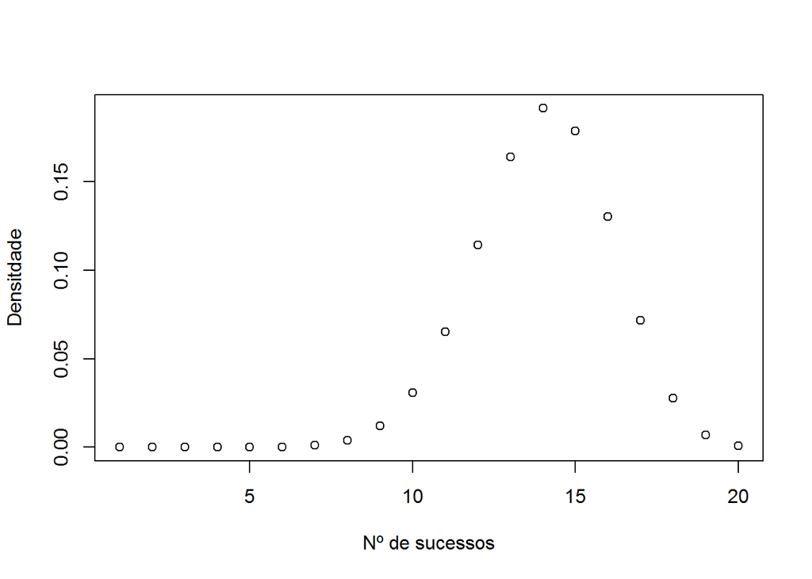

```r
den <- stats::dbinom(1:20, 20, 0.7)
plot(den, ylab = "Densitdade", xlab = "Nº de sucessos")

df <- data.frame(den = den,
                 id = 1:length(den))
library(ggplot2)
```

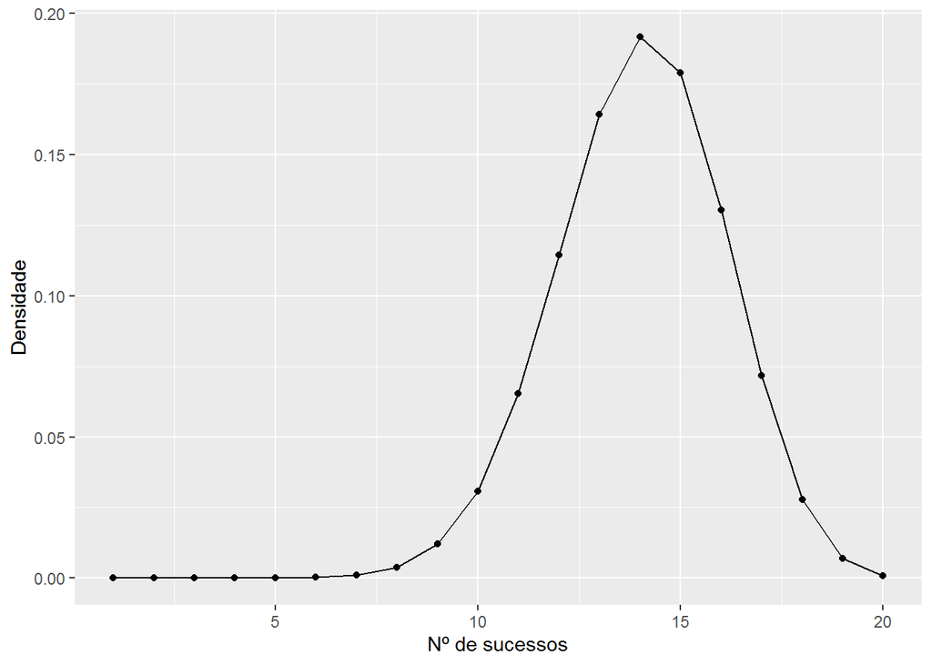

```r
ggplot(df) +
  geom_line(aes(x = id, y = den)) +
  geom_point(aes(x = id, y = den)) +
  xlab("Nº de sucessos") +
  ylab("Densidade")
```

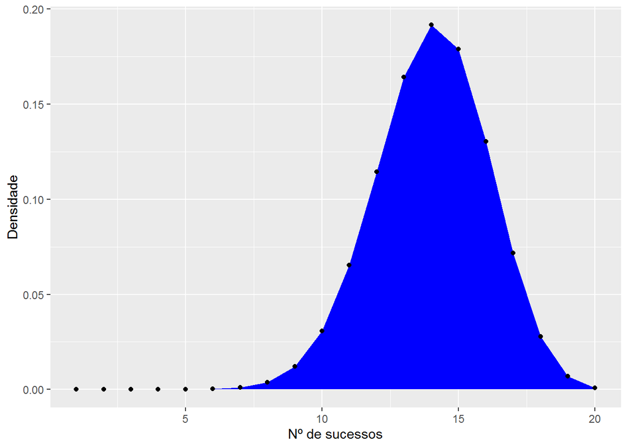

```r
ggplot(df) +
  geom_area(aes(x = id, y = den), fill = "blue") +
  geom_point(aes(x = id, y = den)) +
  xlab("Nº de sucessos") +
  ylab("Densidade")
```

Trabalhando com a manipulação de dados, é possível plotar a máxima densidade de uma maneira bem simples utilizando o pacote `dplyr` e funções residentes no R.

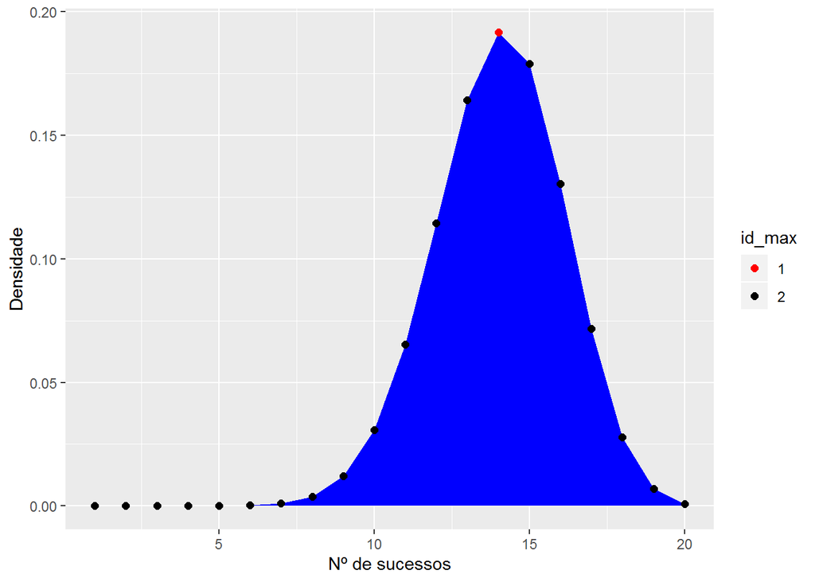

```r
library(dplyr)

df2 <- df %>%
  dplyr::arrange(dplyr::desc(den)) %>%
  dplyr::mutate(id_max = as.factor(c(1, rep(2, 19))))

ggplot(df2) +
  geom_area(aes(x = id, y = den), fill = "blue") +
  geom_point(aes(x = id, y = den, col = id_max), size = 2) +
  scale_color_manual(values = c("red", "black")) +
  xlab("Nº de sucessos") +
  ylab("Densidade")
```

Adaptado de:[*Fonte*](https://www.r-bloggers.com/probability-distributions-in-r/)

### CONSIDERAÇÕES FINAIS

A aplicação de probabilidade em R, nesta parte introdutória, pode ser bastante simples e prática. Podemos obter resultados com excelente precisão numérica, rapidez e com uma linguagem computacional de baixa complexidade.  
A utilização de ferramentas gráficas podem proporcionar melhor análise, e nos permite também expressar, de melhor maneira, os resultados obtidos.